# 家庭環境の変化が子どもの不登校に与える影響：都道府県別データによる計量分析

1A231071-2 大山楓子

```r
library(interplot)
library(jtools)
library(margins)
library(msm)
library(patchwork)
library(stargazer)
library(tidyverse)
library(knitr)
library(dplyr)
library(ggplot2)
```

### はじめに

分析の背景 2024年度の小・中学校における不登校児童・生徒数は、過去最多の34万人を記録するなど、子どもの不登校の増加は日本社会で喫緊の課題になっており、政府がさまざまな対策を講じているが、改善の兆しは見えない。子どもが不登校に至る要因は多岐にわたるが、その中でも家庭内での出来事が子どもの身体・心理に大きな影響を及ぼしていることは明確である。家庭環境に関する状況においても、親子の関わり方や家族関係の変化という要因が大きな影響力を持つため、重視されるべきである。本稿では、家庭環境に変化をもたらすきっかけの一つである両親の離婚に注目し、それが子どもの心理的状況、ひいては不登校をはじめとする社会との関わり方にどのような影響を及ぼすかを分析する。

### 理論

離婚が子どもの精神的ストレスを増大させるきっかけとなり、結果的に不登校になるというメカニズムから、離婚率が上昇すると子どもの不登校率も上昇するという理論が成り立つ。この理論を元に分析を行う。また、大都市か否かという要因と教員一人当たりの生徒数も説明変数として加えることで、離婚率が不登校率に与える影響が学習環境によって変化するのかを検討する。

### 仮説

離婚率の上昇に伴い、中学校における生徒の不登校率は上昇するが、教員一人当たりの生徒数が多いほど顕著になる。

### データ

データの収集 分析を行う上で必要な統計データは、e-Stat（政府統計の総合窓口）を通して収集する。 収集したデータは、2022年度の中学校における不登校率、2022年度の離婚率、2022年度の教員一人当たりの中学生数である。

```r
#データの読み込み
hr2022 <- read_csv("data/merged_2022.csv")
```

```r
# 大都市都道府県のリストを定義
major_prefectures <- c("埼玉県", "千葉県", "東京都", "神奈川県", "愛知県", "京都府", "大阪府", "兵庫県", "福岡県")

# ダミー変数を作成
hr2022 <- hr2022 %>%
  mutate(majorpref = ifelse(pref %in% major_prefectures, 1, 0)) %>%
# 分析に必要な変数を選択
  dplyr::select(truancy, divorce, studentnum, majorpref)

# 結果を確認
head(hr2022)
```

```
# A tibble: 6 × 4
  truancy divorce studentnum majorpref
    <dbl>   <dbl>      <dbl>     <dbl>
1    6.39    2.13       12.6         0
2    5.87    1.43       15.5         1
3    5.65    1.7        13.0         1
4    5.43    1.68       13.8         1
5    5.21    1.42       15.2         1
6    5.1     1.44       14.8         1
```

```r
#分析で用いる変数を表示
kable(df, col.names = c("変数の種類", "変数名", "詳細"), align = "c")
```

| 変数の種類 | 変数名 | 詳細 |
| --- | --- | --- |
| 応答変数 | truancy | 中学生の不登校率 (%) |
| 説明変数 | divorce | 離婚率（%） |
| コントロール変数1 | studentnum | 教員一人当たりの生徒数 |
| コントロール変数２ | majorpref | 大都市都道府県ダミー（1 = 埼玉県、千葉県、東京都、神奈川県、愛知県、京都府、大阪府、兵庫県、福岡県、０ = その他の都道府県） |
| 交差項 | divorce:studentnum | 離婚率と教員一人当たりの生徒数を掛け合わせた変数 |

```r
hr2022 <- as.data.frame(hr2022)
```

```r
stargazer(as.data.frame(hr2022),
          type = "html",
          title = "収集データの記述統計",
          digits = 2,
          covariate.labels = c("中学校における不登校率",
                               "離婚率",
                               "教員一人当たりの生徒数",
                               "大都市都道府県ダミー"))
```

**収集データの記述統計**

| Statistic | N | Mean | St. Dev. | Min | Max |
| --- | --- | --- | --- | --- | --- |
| 中学校における不登校率 | 47 | 4.00 | 0.86 | 2.75 | 6.39 |
| 離婚率 | 47 | 1.43 | 0.18 | 1.08 | 2.13 |
| 教員一人当たりの生徒数 | 47 | 12.05 | 1.58 | 8.40 | 15.51 |
| 大都市都道府県ダミー | 47 | 0.19 | 0.40 | 0 | 1 |

```r
F1 <- ggplot(hr2022, aes(divorce, truancy)) +
  geom_point() +
  labs(x = "離婚率（%）", y = "不登校率 (%)",
         title = "離婚率と不登校率") +
  stat_smooth(method = lm, se = FALSE) +
  theme_bw(base_family = "HiraKakuProN-W3")
```

```r
F2 <- ggplot(hr2022, aes(studentnum, truancy)) +
  geom_point() +
  labs(x = "教員一人当たりの生徒数", y = "不登校率 (%)",
         title = "教員一人当たりの生徒数と不登校率") +
  stat_smooth(method = lm, se = FALSE) +
  theme_bw(base_family = "HiraKakuProN-W3")
```

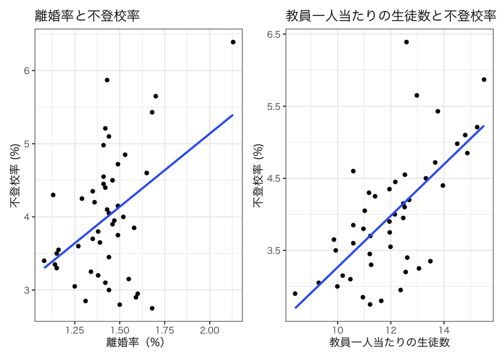

```r
F1 + F2 + plot_layout(ncol = 2)
```

・離婚率と不登校率、教員一人当たりの生徒数と不登校率のそれぞれに正の相関が見られる

### -交差項を含まないモデル(Model_1)

```r
#交差項を含まないモデル(Model_1)
Model_1 <- lm(truancy ~ divorce +
                studentnum +
                majorpref,
              data = hr2022)
```

```r
stargazer(Model_1,
          type = "html")
```

|  | *Dependent variable:* |
| --- | --- |
|  | truancy |
| divorce | 1.498*** |
|  | (0.462) |
| studentnum | 0.219*** |
|  | (0.070) |
| majorpref | 0.707** |
|  | (0.284) |
| Constant | -0.920 |
|  | (1.065) |
| Observations | 47 |
| R<sup>2</sup> | 0.609 |
| Adjusted R<sup>2</sup> | 0.582 |
| Residual Std. Error | 0.558 (df = 43) |
| F Statistic | 22.340*** (df = 3; 43) |
| *Note:* | p<0.1; p<0.05; p<0.01 |

Model1の分析結果 ・離婚率(divorce)の係数(1.498)のp値がp<0.01であることから、統計的に有意であると言える →離婚率が1%増えると不登校率が1.498%ポイント増える

### -交差項を含むモデル(Model_2)

```r
#交差項を含むモデル(Model_2)
Model_2 <- lm(truancy ~ divorce*studentnum +
                majorpref,
              data = hr2022)
```

```r
stargazer(Model_1, Model_2, type = "html")
```

|  | *Dependent variable:* |  |
| --- | --- | --- |
|  | truancy |  |
|  | (1) | (2) |
| divorce | 1.498*** | -9.684** |
|  | (0.462) | (4.517) |
| studentnum | 0.219*** | -1.101** |
|  | (0.070) | (0.535) |
| majorpref | 0.707** | 0.559** |
|  | (0.284) | (0.275) |
| divorce:studentnum |  | 0.935** |
|  |  | (0.376) |
| Constant | -0.920 | 14.867** |
|  | (1.065) | (6.426) |
| Observations | 47 | 47 |
| R<sup>2</sup> | 0.609 | 0.659 |
| Adjusted R<sup>2</sup> | 0.582 | 0.627 |
| Residual Std. Error | 0.558 (df = 43) | 0.527 (df = 42) |
| F Statistic | 22.340*** (df = 3; 43) | 20.322*** (df = 4; 42) |
| *Note:* | p<0.1; p<0.05; p<0.01 |  |

```r
tidy(Model_2)
```

```
# A tibble: 5 × 5
  term               estimate std.error statistic p.value
  <chr>                 <dbl>     <dbl>     <dbl>   <dbl>
1 (Intercept)          14.9       6.43       2.31  0.0257
2 divorce              -9.68      4.52      -2.14  0.0379
3 studentnum           -1.10      0.535     -2.06  0.0458
4 majorpref             0.559     0.275      2.04  0.0481
5 divorce:studentnum    0.935     0.376      2.49  0.0169
```

Model2の分析結果 ・交差項(divorce:studentnum)の係数(0.935)のp値がp>0.01であることから、1%水準においては統計的に有意であるといえない。しかし、5%水準を採用した場合に限っては、統計的に有意 といえる。仮説のための証拠として、弱くはないが非常に強くもない結果であるが、解釈をするならば「離婚率が不登校率に与える影響は、教員一人当たりの生徒数によって異なる」と言える。 →具体的には「離婚率が高い地域では、教員一人当たりの生徒数の影響がより大きい」ということである。

### 分析結果

```r
df_inter <- interplot(m = Model_2, var1 = "divorce", var2 = "studentnum", plot = FALSE)
```

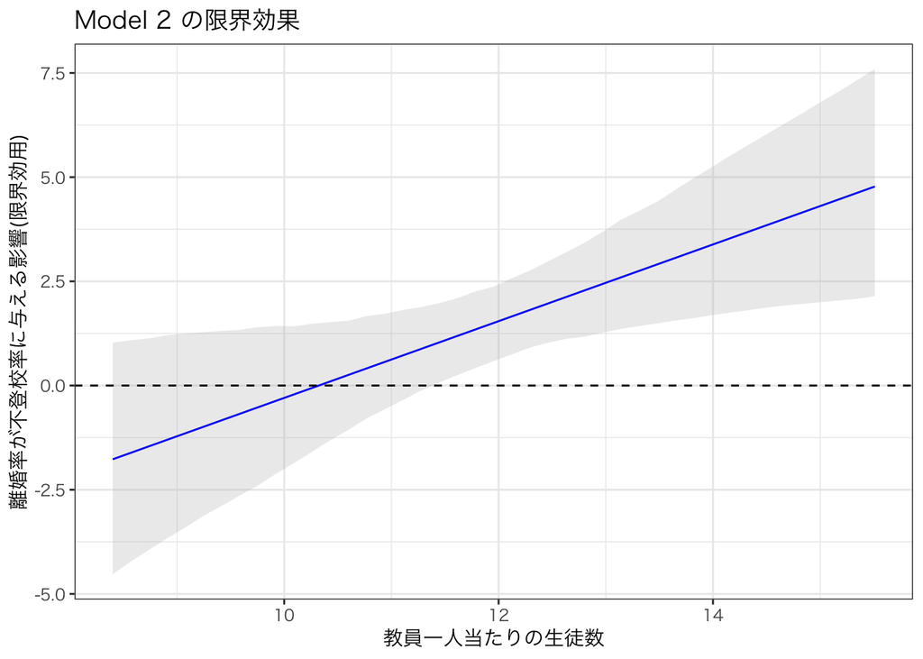

```r
interplot_1 <- ggplot(df_inter, aes(x = studentnum, y = coef)) +
  geom_ribbon(aes(ymin = lb, ymax = ub), alpha = 0.3, fill = "gray") +  # 信頼区間
  geom_line(color = "blue") +  # 交互作用の回帰線
  geom_hline(yintercept = 0, linetype = 2) +  # 基準線
  labs(x = "教員一人当たりの生徒数",
       y = "離婚率が不登校率に与える影響(限界効用)",
       title = "Model 2 の限界効果") +
  ylim(min(df_inter$lb, na.rm = TRUE), max(df_inter$ub, na.rm = TRUE)) +
  theme_bw(base_family = "HiraKakuProN-W3")

interplot_1
```

### 結論

上記の分析から、①離婚率の上昇は、不登校率の上昇と有意に関連する、②教員一人当たりの生徒が不登校率に影響する、③離婚率と教員一人当たりの生徒数の交差項を考慮した場合、効果が変化するという三つのことが明らかとなった。 ①に関して、Model 1（交差項なし） では、離婚率の係数が 1.498（p < 0.01）と統計的に有意であり、これは離婚率が1%増加すると、不登校率が1.498%ポイント増加することを意味する。 ②に関して、Model1(交差項なし）では、教員一人当たりの係数が0.219と統計的に有意であり、これは教員一人当たりの生徒数が１人増加すると不登校率が0.219%ポイント増加することを意味する。 ③に関して、Model2（交差項あり）では、離婚率の単独効果が負になり、交差項 divorce:studentnum の係数（0.935, p = 0.0169）が有意であることから、離婚率の影響は、教員一人当たりの生徒数によって異なるということが言える。つまり、離婚率が高い地域ほど、生徒数が多いと不登校率への影響が大きくなる ということになる。

### おわりに

本研究は、「離婚率」「教員一人当たりの生徒数」「大都市か否か」が中学校の不登校率に影響を与える要因であることを示した。特に、離婚率の影響は教員一人当たりの生徒数の多さによって強まるため、教育環境の整備が不登校対策に有効である可能性を示唆する重要な知見となった。

### 参考文献

浅野正彦(2025).「14.重回帰分析(単回帰と重回帰）」.2025年度早稲田大学「計量分析（政治）」補助教材. https://asanoucla.github.io/R14_reg1.html (参照 2025-02-01)

浅野正彦(2025).「17.重回帰分析3（交差項1）」.2025年度早稲田大学「計量分析（政治）」補助教材. https://asanoucla.github.io/R17_reg4_interaction1.html (参照 2025-02-01)

浅野正彦(2025).「18.重回帰分析4（交差項2）」.2025年度早稲田大学「計量分析（政治）」補助教材. https://asanoucla.github.io/R17_reg4_interaction1.html (参照 2025-02-02)

小川 一夫. (2015年). 失業と学校教育における人的資本形成: 都道府県別パネルデータによる計量分析. 日本労働研究雑誌, 57(2–3), 37–53.